# Human Activity Data - Weight Lifting

Gaurav Chaturvedi

Saturday, July 25, 2015

## Summary

The objective of this exercise was to develop a machine learning algorithm to predict quality of execution of a barbell lift (split in 5 classes).

Of the 160 features, only 52 predictors were ultimately used as the rest had majority of NA values. Predictors related to users and timestamp were also ignored. Principal Component Analysis was used to pre-process the data.

Random Forest algorithm was used to predict on the validation set.

## Study Design

We have been provided a training set with 19622 observations and a validation set with 20 observations.

For building the Machine Learning algorithm, the training set has been further split into training (70%) and testing (30%).

## Data Reading

Data is read and further sub-divided into training and testing.

```r
library(caret)
library(rattle)
library(randomForest)

iotdata <- read.csv("../Data/pml-training.csv", header=TRUE)
inTrain <- createDataPartition(y=iotdata$classe, p=0.7, list=FALSE)
training <- iotdata[inTrain,]
testing <- iotdata[-inTrain,]
```

## Feature Clean-up

The following clean-up is done 1. Remove the user and timestamp related variables. Assumption here is that user level differences are not material since all repetitions have been supervised by an expert

2. Some numerci features are read as factors due to presence of #div0 error. So converting back to numeric
3. A lot of features have a lot of NA values (>80% values are NA). These features have to be removed

```r
## 1. remove the user and timestamp variables from training data set
trainoutcome <- training$classe # capture outcome before removing it
training <- training[,-c(1:7, 160)] # remove useless vars and outcome

 ## Convert factors to numeric
asNumeric <- function(x) as.numeric(as.character(x))
factorsNumeric <- function(d) modifyList(d, lapply(d[, sapply(d, is.factor)],                                     asNumeric))
training <- factorsNumeric(training)

## Remove Cols with high number of NAs (>80% NAs)
na_count <-sapply(training, function(y) sum(length(which(is.na(y)))))
na_count <- data.frame(na_count)
disccols <- row.names(na_count[na_count$na_count > 0.8*nrow(training),,drop=FALSE])
training <- training[ , -which(names(training) %in% disccols)] # remove cols with mostly NAs
```

Outcome - We are now left with 52 of the 160 features

## Covariate Creation

We do the following steps to create covariates:

1. Check for near zero vars

```r
## Check for near Zero Vars
nsv <- nearZeroVar(training, saveMetrics=TRUE)
nsv
```

There are no variables with near zero variation (results hidden as very long).

2. Check for highly co-related variables

```r
## Check for high correlation
M <- abs(cor(training[,-c(1:7,160)]))
diag(M) <- 0
which(M>0, arr.ind=T)
```

There are pairs with high correlation (results hidden as very long). So PCA can be used to reduce # vars

## Preprocessing with PCA

```r
# Apply PCA
preProc <- preProcess(training, method="pca", thresh=0.90)
preProc
```

```
##
## Call:
## preProcess.default(x = training, method = "pca", thresh = 0.9)
##
## Created from 13737 samples and 52 variables
## Pre-processing: principal component signal extraction, scaled, centered
##
## PCA needed 18 components to capture 90 percent of the variance
```

We now have the preProc varaible with the principal components. We use this for model fitment.

## Model Fitment

I try two models -> Classification Trees (rpart) and Random Forest (RF).

```r
trainPC <- predict(preProc, training)
training$classe <- trainoutcome
```

### Classification Trees

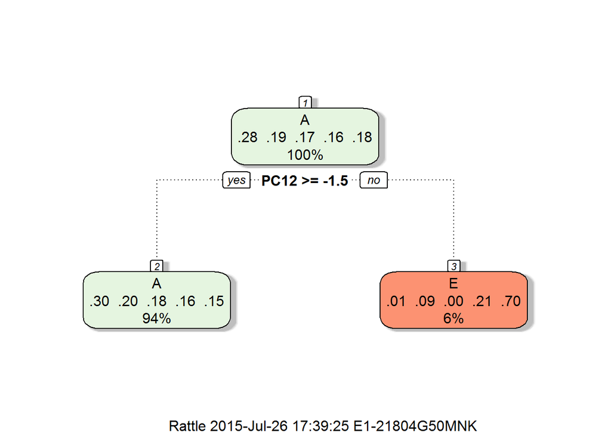

```r
modFit1 <- train(training$classe ~ ., method = "rpart", data=trainPC)
fancyRpartPlot(modFit1$finalModel)
```

```r
modFit1$results
```

```
##           cp  Accuracy     Kappa AccuracySD    KappaSD
## 1 0.03722917 0.3740352 0.1723505 0.04303403 0.07509086
## 2 0.03758519 0.3740352 0.1723505 0.04303403 0.07509086
## 3 0.05289391 0.3461290 0.1158392 0.03234376 0.05815721
```

As we can see the accuracy of the classification tree on training set is very low. We expect the accuracy to be lower on the testing set. Hence we discard this algorithm.

### Random Forest

```r
#modFit2 <- train(training$classe ~ ., method = "rf", data=trainPC)
modFit2 <- randomForest(y=training$classe, x = trainPC, ntree=1000)
p1 <- predict(modFit2, newdata=trainPC)
confusionMatrix(training$classe, p1)
```

```
## Confusion Matrix and Statistics
##
##           Reference
## Prediction    A    B    C    D    E
##          A 3906    0    0    0    0
##          B    0 2658    0    0    0
##          C    0    0 2396    0    0
##          D    0    0    0 2252    0
##          E    0    0    0    0 2525
##
## Overall Statistics
##
##                Accuracy : 1
##                  95% CI : (0.9997, 1)
##     No Information Rate : 0.2843
##     P-Value [Acc > NIR] : < 2.2e-16
##
##                   Kappa : 1
##  Mcnemar's Test P-Value : NA
##
## Statistics by Class:
##
##                      Class: A Class: B Class: C Class: D Class: E
## Sensitivity            1.0000   1.0000   1.0000   1.0000   1.0000
## Specificity            1.0000   1.0000   1.0000   1.0000   1.0000
## Pos Pred Value         1.0000   1.0000   1.0000   1.0000   1.0000
## Neg Pred Value         1.0000   1.0000   1.0000   1.0000   1.0000
## Prevalence             0.2843   0.1935   0.1744   0.1639   0.1838
## Detection Rate         0.2843   0.1935   0.1744   0.1639   0.1838
## Detection Prevalence   0.2843   0.1935   0.1744   0.1639   0.1838
## Balanced Accuracy      1.0000   1.0000   1.0000   1.0000   1.0000
```

The accuracy of RF algoithm on training set is very high. We cross validate this with the testing set.

The variable importance plot is below:

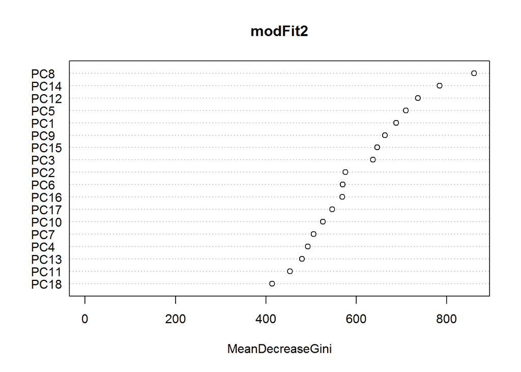

```r
varImpPlot(modFit2,)
```

## Model Evaluation

```r
testoutcome <- testing$classe # capture test outcome before removing it
testing <- testing[,-c(1:7, 160)] # remove useless vars and outcome
testing <- testing[ , -which(names(testing) %in% disccols)] # remove cols with mostly NAs in training set

testPC <- predict(preProc, testing)
testing$classe <- testoutcome
```

### Random Forest

```r
p2 <- predict(modFit2, newdata=testPC)
confusionMatrix(testing$classe, p2)
```

```
## Confusion Matrix and Statistics
##
##           Reference
## Prediction    A    B    C    D    E
##          A 1650   14   10    0    0
##          B   28 1089   17    0    5
##          C    8   11  999    4    4
##          D    5    3   37  917    2
##          E    0    3    9    6 1064
##
## Overall Statistics
##
##                Accuracy : 0.9718
##                  95% CI : (0.9672, 0.9759)
##     No Information Rate : 0.2873
##     P-Value [Acc > NIR] : < 2.2e-16
##
##                   Kappa : 0.9643
##  Mcnemar's Test P-Value : NA
##
## Statistics by Class:
##
##                      Class: A Class: B Class: C Class: D Class: E
## Sensitivity            0.9758   0.9723   0.9319   0.9892   0.9898
## Specificity            0.9943   0.9895   0.9944   0.9905   0.9963
## Pos Pred Value         0.9857   0.9561   0.9737   0.9512   0.9834
## Neg Pred Value         0.9903   0.9935   0.9850   0.9980   0.9977
## Prevalence             0.2873   0.1903   0.1822   0.1575   0.1827
## Detection Rate         0.2804   0.1850   0.1698   0.1558   0.1808
## Detection Prevalence   0.2845   0.1935   0.1743   0.1638   0.1839
## Balanced Accuracy      0.9850   0.9809   0.9631   0.9899   0.9930
```

## Conclusion - Outcome on the validation set

Random Forest algorithm has high accuracy on the testing and training set.

I use this algorithm to find answers to the 20 observations in the validation set and submit for grading !

```r
validation = read.csv("../Data/pml-testing.csv", header=TRUE)

# Perform the transformation operations on this set

valoutcome <- validation$classe # capture test outcome before removing it
validation <- validation[,-c(1:7, 160)] # remove useless vars and outcome
validation <- validation[ , -which(names(validation) %in% disccols)] # remove cols with mostly NAs in training set

# PCA on the validation setusing preProc object from training set
validationPC <- predict(preProc, validation)
validation$classe <- valoutcome

p2 <- predict(modFit2, newdata=validationPC)
```